# INN_Learner_Notebook_Full_code_completed

### Neural Network with Balanced Data (by applying SMOTE) and Adam Optimizer

```python
# Balancing the class weights using smote
sm = SMOTE(random_state=42)
X_train_sm, y_train_sm = sm.fit_resample(X_train, y_train)
X_train_sm.shape, y_train_sm.shape
```

```
((10192, 11), (10192,))
```

```python
model = Sequential()
model.add(Dense(100, activation='relu', input_dim=X_train.shape[1]))
model.add(Dense(100, activation='relu'))
model.add(Dense(1, activation='sigmoid'))

model.summary()
```

```
Model: "sequential_6"
```

```
┏━━━━━━━━━━━━━━━━━━━━━━━━━━━━━━━━━━━━━━┳━━━━━━━━━━━━━━━━━━━━━━━━━━━━━┳━━━━━━━━━━━━━━━━━┓
┃ Layer (type)                         ┃ Output Shape                ┃         Param # ┃
┡━━━━━━━━━━━━━━━━━━━━━━━━━━━━━━━━━━━━━━╇━━━━━━━━━━━━━━━━━━━━━━━━━━━━━╇━━━━━━━━━━━━━━━━━┩
│ dense_18 (Dense)                     │ (None, 100)                 │           1,200 │
├──────────────────────────────────────┼─────────────────────────────┼─────────────────┤
│ dense_19 (Dense)                     │ (None, 100)                 │          10,100 │
├──────────────────────────────────────┼─────────────────────────────┼─────────────────┤
│ dense_20 (Dense)                     │ (None, 1)                   │             101 │
└──────────────────────────────────────┴─────────────────────────────┴─────────────────┘
```

```
 Total params: 11,401 (44.54 KB)
```

```
 Trainable params: 11,401 (44.54 KB)
```

```
 Non-trainable params: 0 (0.00 B)
```

```python
model.compile(optimizer='adam', loss='binary_crossentropy', metrics=['accuracy'])
```

```python
start = time.time()
model_history = model.fit(X_train_sm, y_train_sm, epochs=epochs, batch_size=batch_size, validation_data=(X_val, y_val))
end = time.time()
```

```
319/319 ━━━━━━━━━━━━━━━━━━━━ 2s 3ms/step - accuracy: 0.7105 - loss: 0.5620 - val_accuracy: 0.7844 - val_loss: 0.4675
319/319 ━━━━━━━━━━━━━━━━━━━━ 1s 2ms/step - accuracy: 0.7874 - loss: 0.4538 - val_accuracy: 0.7925 - val_loss: 0.4476
319/319 ━━━━━━━━━━━━━━━━━━━━ 1s 4ms/step - accuracy: 0.7974 - loss: 0.4356 - val_accuracy: 0.7994 - val_loss: 0.4408
319/319 ━━━━━━━━━━━━━━━━━━━━ 1s 4ms/step - accuracy: 0.8031 - loss: 0.4227 - val_accuracy: 0.8025 - val_loss: 0.4363
319/319 ━━━━━━━━━━━━━━━━━━━━ 1s 4ms/step - accuracy: 0.8101 - loss: 0.4111 - val_accuracy: 0.8075 - val_loss: 0.4323
319/319 ━━━━━━━━━━━━━━━━━━━━ 1s 4ms/step - accuracy: 0.8144 - loss: 0.4004 - val_accuracy: 0.8112 - val_loss: 0.4288
319/319 ━━━━━━━━━━━━━━━━━━━━ 2s 2ms/step - accuracy: 0.8208 - loss: 0.3898 - val_accuracy: 0.8156 - val_loss: 0.4259
319/319 ━━━━━━━━━━━━━━━━━━━━ 1s 2ms/step - accuracy: 0.8279 - loss: 0.3799 - val_accuracy: 0.8138 - val_loss: 0.4259
319/319 ━━━━━━━━━━━━━━━━━━━━ 1s 2ms/step - accuracy: 0.8330 - loss: 0.3706 - val_accuracy: 0.8144 - val_loss: 0.4259
319/319 ━━━━━━━━━━━━━━━━━━━━ 1s 3ms/step - accuracy: 0.8394 - loss: 0.3608 - val_accuracy: 0.8175 - val_loss: 0.4269
319/319 ━━━━━━━━━━━━━━━━━━━━ 1s 2ms/step - accuracy: 0.8435 - loss: 0.3516 - val_accuracy: 0.8181 - val_loss: 0.4288
319/319 ━━━━━━━━━━━━━━━━━━━━ 1s 2ms/step - accuracy: 0.8487 - loss: 0.3428 - val_accuracy: 0.8181 - val_loss: 0.4307
319/319 ━━━━━━━━━━━━━━━━━━━━ 1s 2ms/step - accuracy: 0.8544 - loss: 0.3340 - val_accuracy: 0.8163 - val_loss: 0.4342
319/319 ━━━━━━━━━━━━━━━━━━━━ 1s 2ms/step - accuracy: 0.8582 - loss: 0.3254 - val_accuracy: 0.8200 - val_loss: 0.4360
319/319 ━━━━━━━━━━━━━━━━━━━━ 2s 4ms/step - accuracy: 0.8607 - loss: 0.3176 - val_accuracy: 0.8200 - val_loss: 0.4403
319/319 ━━━━━━━━━━━━━━━━━━━━ 1s 4ms/step - accuracy: 0.8648 - loss: 0.3099 - val_accuracy: 0.8206 - val_loss: 0.4449
319/319 ━━━━━━━━━━━━━━━━━━━━ 1s 4ms/step - accuracy: 0.8686 - loss: 0.3023 - val_accuracy: 0.8181 - val_loss: 0.4492
319/319 ━━━━━━━━━━━━━━━━━━━━ 1s 4ms/step - accuracy: 0.8700 - loss: 0.2950 - val_accuracy: 0.8188 - val_loss: 0.4534
319/319 ━━━━━━━━━━━━━━━━━━━━ 1s 3ms/step - accuracy: 0.8733 - loss: 0.2882 - val_accuracy: 0.8175 - val_loss: 0.4562
319/319 ━━━━━━━━━━━━━━━━━━━━ 1s 2ms/step - accuracy: 0.8774 - loss: 0.2817 - val_accuracy: 0.8163 - val_loss: 0.4606
319/319 ━━━━━━━━━━━━━━━━━━━━ 1s 2ms/step - accuracy: 0.8800 - loss: 0.2752 - val_accuracy: 0.8188 - val_loss: 0.4637
319/319 ━━━━━━━━━━━━━━━━━━━━ 1s 2ms/step - accuracy: 0.8833 - loss: 0.2693 - val_accuracy: 0.8169 - val_loss: 0.4686
319/319 ━━━━━━━━━━━━━━━━━━━━ 1s 2ms/step - accuracy: 0.8854 - loss: 0.2634 - val_accuracy: 0.8169 - val_loss: 0.4724
319/319 ━━━━━━━━━━━━━━━━━━━━ 1s 2ms/step - accuracy: 0.8899 - loss: 0.2581 - val_accuracy: 0.8163 - val_loss: 0.4763
319/319 ━━━━━━━━━━━━━━━━━━━━ 1s 2ms/step - accuracy: 0.8914 - loss: 0.2525 - val_accuracy: 0.8175 - val_loss: 0.4818
319/319 ━━━━━━━━━━━━━━━━━━━━ 1s 2ms/step - accuracy: 0.8939 - loss: 0.2472 - val_accuracy: 0.8169 - val_loss: 0.4859
319/319 ━━━━━━━━━━━━━━━━━━━━ 1s 2ms/step - accuracy: 0.8967 - loss: 0.2423 - val_accuracy: 0.8150 - val_loss: 0.4915
319/319 ━━━━━━━━━━━━━━━━━━━━ 2s 4ms/step - accuracy: 0.8978 - loss: 0.2374 - val_accuracy: 0.8169 - val_loss: 0.4958
319/319 ━━━━━━━━━━━━━━━━━━━━ 1s 3ms/step - accuracy: 0.9014 - loss: 0.2327 - val_accuracy: 0.8181 - val_loss: 0.5008
319/319 ━━━━━━━━━━━━━━━━━━━━ 1s 4ms/step - accuracy: 0.9042 - loss: 0.2276 - val_accuracy: 0.8169 - val_loss: 0.5063
319/319 ━━━━━━━━━━━━━━━━━━━━ 2s 2ms/step - accuracy: 0.9078 - loss: 0.2234 - val_accuracy: 0.8163 - val_loss: 0.5115
319/319 ━━━━━━━━━━━━━━━━━━━━ 1s 2ms/step - accuracy: 0.9095 - loss: 0.2189 - val_accuracy: 0.8156 - val_loss: 0.5160
319/319 ━━━━━━━━━━━━━━━━━━━━ 1s 2ms/step - accuracy: 0.9103 - loss: 0.2145 - val_accuracy: 0.8181 - val_loss: 0.5226
319/319 ━━━━━━━━━━━━━━━━━━━━ 1s 2ms/step - accuracy: 0.9119 - loss: 0.2107 - val_accuracy: 0.8188 - val_loss: 0.5285
319/319 ━━━━━━━━━━━━━━━━━━━━ 1s 2ms/step - accuracy: 0.9153 - loss: 0.2067 - val_accuracy: 0.8144 - val_loss: 0.5342
319/319 ━━━━━━━━━━━━━━━━━━━━ 1s 2ms/step - accuracy: 0.9175 - loss: 0.2028 - val_accuracy: 0.8144 - val_loss: 0.5391
319/319 ━━━━━━━━━━━━━━━━━━━━ 1s 2ms/step - accuracy: 0.9206 - loss: 0.1990 - val_accuracy: 0.8163 - val_loss: 0.5453
319/319 ━━━━━━━━━━━━━━━━━━━━ 1s 2ms/step - accuracy: 0.9217 - loss: 0.1954 - val_accuracy: 0.8138 - val_loss: 0.5502
319/319 ━━━━━━━━━━━━━━━━━━━━ 1s 2ms/step - accuracy: 0.9237 - loss: 0.1917 - val_accuracy: 0.8156 - val_loss: 0.5557
319/319 ━━━━━━━━━━━━━━━━━━━━ 2s 4ms/step - accuracy: 0.9236 - loss: 0.1884 - val_accuracy: 0.8144 - val_loss: 0.5615
```

[output cut: 45 more lines]

```
319/319 ━━━━━━━━━━━━━━━━━━━━ 1s 2ms/step - accuracy: 0.9712 - loss: 0.0912 - val_accuracy: 0.8144 - val_loss: 0.8391
319/319 ━━━━━━━━━━━━━━━━━━━━ 1s 2ms/step - accuracy: 0.9699 - loss: 0.0905 - val_accuracy: 0.8131 - val_loss: 0.8471
319/319 ━━━━━━━━━━━━━━━━━━━━ 1s 2ms/step - accuracy: 0.9703 - loss: 0.0891 - val_accuracy: 0.8125 - val_loss: 0.8511
319/319 ━━━━━━━━━━━━━━━━━━━━ 1s 3ms/step - accuracy: 0.9716 - loss: 0.0875 - val_accuracy: 0.8144 - val_loss: 0.8593
319/319 ━━━━━━━━━━━━━━━━━━━━ 1s 3ms/step - accuracy: 0.9718 - loss: 0.0869 - val_accuracy: 0.8138 - val_loss: 0.8651
319/319 ━━━━━━━━━━━━━━━━━━━━ 1s 4ms/step - accuracy: 0.9720 - loss: 0.0854 - val_accuracy: 0.8125 - val_loss: 0.8705
319/319 ━━━━━━━━━━━━━━━━━━━━ 1s 4ms/step - accuracy: 0.9732 - loss: 0.0843 - val_accuracy: 0.8119 - val_loss: 0.8767
319/319 ━━━━━━━━━━━━━━━━━━━━ 2s 2ms/step - accuracy: 0.9748 - loss: 0.0829 - val_accuracy: 0.8125 - val_loss: 0.8863
319/319 ━━━━━━━━━━━━━━━━━━━━ 1s 2ms/step - accuracy: 0.9749 - loss: 0.0813 - val_accuracy: 0.8138 - val_loss: 0.8919
319/319 ━━━━━━━━━━━━━━━━━━━━ 1s 2ms/step - accuracy: 0.9744 - loss: 0.0806 - val_accuracy: 0.8112 - val_loss: 0.8966
319/319 ━━━━━━━━━━━━━━━━━━━━ 1s 2ms/step - accuracy: 0.9756 - loss: 0.0798 - val_accuracy: 0.8106 - val_loss: 0.9021
319/319 ━━━━━━━━━━━━━━━━━━━━ 1s 2ms/step - accuracy: 0.9756 - loss: 0.0785 - val_accuracy: 0.8138 - val_loss: 0.9078
319/319 ━━━━━━━━━━━━━━━━━━━━ 1s 2ms/step - accuracy: 0.9768 - loss: 0.0776 - val_accuracy: 0.8119 - val_loss: 0.9169
319/319 ━━━━━━━━━━━━━━━━━━━━ 1s 2ms/step - accuracy: 0.9770 - loss: 0.0768 - val_accuracy: 0.8138 - val_loss: 0.9217
319/319 ━━━━━━━━━━━━━━━━━━━━ 1s 2ms/step - accuracy: 0.9787 - loss: 0.0751 - val_accuracy: 0.8119 - val_loss: 0.9274
```

```python
print("Time taken in seconds", end-start)
```

```
Time taken in seconds 123.15786957740784
```

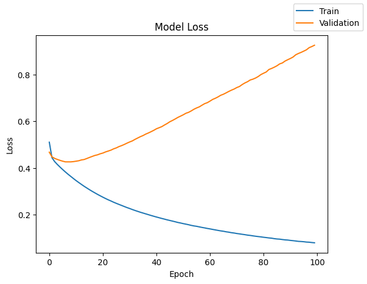

```python
plot(model_history, 'loss')
```

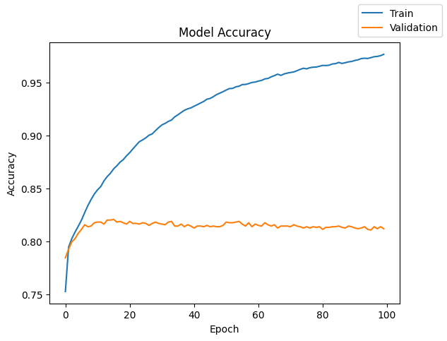

```python
plot(model_history, 'accuracy')
```

```python
model_5_train_perf = model_performance_classification(model, X_train_sm, y_train_sm)
model_5_train_perf
```

```
319/319 ━━━━━━━━━━━━━━━━━━━━ 1s 2ms/step
```

|  | Accuracy | Recall | Precision | F1 Score |
| --- | --- | --- | --- | --- |
| 0 | 0.970859 | 0.970859 | 0.971045 | 0.970857 |

```python
model_5_valid_perf = model_performance_classification(model, X_val, y_val)
model_5_valid_perf
```

```
50/50 ━━━━━━━━━━━━━━━━━━━━ 0s 1ms/step
```

|  | Accuracy | Recall | Precision | F1 Score |
| --- | --- | --- | --- | --- |
| 0 | 0.811875 | 0.811875 | 0.812955 | 0.812406 |

```python
results.loc[5] = ["NN with Adam and SMOTE",2,'100','relu',100,32,model_history.history["loss"][-1],model_history.history["val_loss"][-1],model_history.history["accuracy"][-1],model_history.history["val_accuracy"][-1],round(end-start,2)]
results[0:6]
```

[output not shown]

### Neural Network with Balanced Data (by applying SMOTE), Adam Optimizer, and Dropout

```python
sm = SMOTE(random_state=42)
X_train_sm, y_train_sm = sm.fit_resample(X_train, y_train)
X_train_sm.shape, y_train_sm.shape
```

```
((10192, 11), (10192,))
```

```python
model = Sequential()
model.add(Dense(100, activation = "relu", input_dim = X_train_sm.shape[1]))
model.add(Dropout(0.4))
model.add(Dense(100, activation = "tanh"))
model.add(Dropout(0.4))
model.add(Dense(100, activation='relu'))
model.add(Dropout(0.2))
model.add(Dense(1, activation="sigmoid"))
model.summary()
```

```
Model: "sequential_11"
```

```
┏━━━━━━━━━━━━━━━━━━━━━━━━━━━━━━━━━━━━━━┳━━━━━━━━━━━━━━━━━━━━━━━━━━━━━┳━━━━━━━━━━━━━━━━━┓
┃ Layer (type)                         ┃ Output Shape                ┃         Param # ┃
┡━━━━━━━━━━━━━━━━━━━━━━━━━━━━━━━━━━━━━━╇━━━━━━━━━━━━━━━━━━━━━━━━━━━━━╇━━━━━━━━━━━━━━━━━┩
│ dense_26 (Dense)                     │ (None, 100)                 │           1,200 │
├──────────────────────────────────────┼─────────────────────────────┼─────────────────┤
│ dropout_2 (Dropout)                  │ (None, 100)                 │               0 │
├──────────────────────────────────────┼─────────────────────────────┼─────────────────┤
│ dense_27 (Dense)                     │ (None, 100)                 │          10,100 │
├──────────────────────────────────────┼─────────────────────────────┼─────────────────┤
│ dropout_3 (Dropout)                  │ (None, 100)                 │               0 │
├──────────────────────────────────────┼─────────────────────────────┼─────────────────┤
│ dense_28 (Dense)                     │ (None, 100)                 │          10,100 │
├──────────────────────────────────────┼─────────────────────────────┼─────────────────┤
│ dropout_4 (Dropout)                  │ (None, 100)                 │               0 │
├──────────────────────────────────────┼─────────────────────────────┼─────────────────┤
│ dense_29 (Dense)                     │ (None, 1)                   │             101 │
└──────────────────────────────────────┴─────────────────────────────┴─────────────────┘
```

```
 Total params: 21,501 (83.99 KB)
```

```
 Trainable params: 21,501 (83.99 KB)
```

```
 Non-trainable params: 0 (0.00 B)
```

```python
model.compile(optimizer="adam",loss="binary_crossentropy", metrics=['accuracy', 'recall'] )
```

```python
start = time.time()
model_history = model.fit(X_train_sm, y_train_sm, epochs = epochs, batch_size = batch_size, validation_data = (X_val, y_val))
end = time.time()
```

```
319/319 ━━━━━━━━━━━━━━━━━━━━ 6s 6ms/step - accuracy: 0.6674 - loss: 0.6062 - recall: 0.7056 - val_accuracy: 0.7419 - val_loss: 0.5152 - val_recall: 0.7485
319/319 ━━━━━━━━━━━━━━━━━━━━ 2s 5ms/step - accuracy: 0.7362 - loss: 0.5278 - recall: 0.7428 - val_accuracy: 0.7675 - val_loss: 0.4663 - val_recall: 0.7239
319/319 ━━━━━━━━━━━━━━━━━━━━ 3s 4ms/step - accuracy: 0.7608 - loss: 0.4973 - recall: 0.7617 - val_accuracy: 0.7950 - val_loss: 0.4592 - val_recall: 0.7209
319/319 ━━━━━━━━━━━━━━━━━━━━ 2s 3ms/step - accuracy: 0.7702 - loss: 0.4839 - recall: 0.7568 - val_accuracy: 0.7919 - val_loss: 0.4481 - val_recall: 0.6963
319/319 ━━━━━━━━━━━━━━━━━━━━ 1s 3ms/step - accuracy: 0.7756 - loss: 0.4747 - recall: 0.7598 - val_accuracy: 0.7881 - val_loss: 0.4665 - val_recall: 0.6994
319/319 ━━━━━━━━━━━━━━━━━━━━ 1s 3ms/step - accuracy: 0.7734 - loss: 0.4688 - recall: 0.7578 - val_accuracy: 0.7962 - val_loss: 0.4509 - val_recall: 0.6779
319/319 ━━━━━━━━━━━━━━━━━━━━ 1s 3ms/step - accuracy: 0.7835 - loss: 0.4594 - recall: 0.7606 - val_accuracy: 0.7975 - val_loss: 0.4458 - val_recall: 0.6779
319/319 ━━━━━━━━━━━━━━━━━━━━ 1s 3ms/step - accuracy: 0.7886 - loss: 0.4551 - recall: 0.7767 - val_accuracy: 0.8000 - val_loss: 0.4512 - val_recall: 0.6871
319/319 ━━━━━━━━━━━━━━━━━━━━ 1s 3ms/step - accuracy: 0.7935 - loss: 0.4540 - recall: 0.7810 - val_accuracy: 0.8012 - val_loss: 0.4389 - val_recall: 0.6963
319/319 ━━━━━━━━━━━━━━━━━━━━ 1s 3ms/step - accuracy: 0.7905 - loss: 0.4515 - recall: 0.7735 - val_accuracy: 0.7962 - val_loss: 0.4497 - val_recall: 0.6840
319/319 ━━━━━━━━━━━━━━━━━━━━ 1s 3ms/step - accuracy: 0.7935 - loss: 0.4440 - recall: 0.7830 - val_accuracy: 0.7937 - val_loss: 0.4419 - val_recall: 0.6963
319/319 ━━━━━━━━━━━━━━━━━━━━ 1s 4ms/step - accuracy: 0.7931 - loss: 0.4482 - recall: 0.7802 - val_accuracy: 0.7987 - val_loss: 0.4450 - val_recall: 0.6718
319/319 ━━━━━━━━━━━━━━━━━━━━ 2s 5ms/step - accuracy: 0.7971 - loss: 0.4421 - recall: 0.7870 - val_accuracy: 0.7906 - val_loss: 0.4502 - val_recall: 0.7025
319/319 ━━━━━━━━━━━━━━━━━━━━ 2s 4ms/step - accuracy: 0.7925 - loss: 0.4376 - recall: 0.7907 - val_accuracy: 0.7981 - val_loss: 0.4490 - val_recall: 0.7025
319/319 ━━━━━━━━━━━━━━━━━━━━ 1s 3ms/step - accuracy: 0.7971 - loss: 0.4295 - recall: 0.7894 - val_accuracy: 0.8031 - val_loss: 0.4470 - val_recall: 0.6933
319/319 ━━━━━━━━━━━━━━━━━━━━ 1s 3ms/step - accuracy: 0.7968 - loss: 0.4378 - recall: 0.7928 - val_accuracy: 0.8019 - val_loss: 0.4425 - val_recall: 0.6963
319/319 ━━━━━━━━━━━━━━━━━━━━ 1s 3ms/step - accuracy: 0.7977 - loss: 0.4406 - recall: 0.7944 - val_accuracy: 0.7962 - val_loss: 0.4394 - val_recall: 0.6687
319/319 ━━━━━━━━━━━━━━━━━━━━ 1s 3ms/step - accuracy: 0.8010 - loss: 0.4298 - recall: 0.7889 - val_accuracy: 0.7987 - val_loss: 0.4441 - val_recall: 0.7025
319/319 ━━━━━━━━━━━━━━━━━━━━ 1s 3ms/step - accuracy: 0.7979 - loss: 0.4283 - recall: 0.7865 - val_accuracy: 0.8075 - val_loss: 0.4446 - val_recall: 0.6718
319/319 ━━━━━━━━━━━━━━━━━━━━ 1s 3ms/step - accuracy: 0.8014 - loss: 0.4274 - recall: 0.7914 - val_accuracy: 0.8012 - val_loss: 0.4542 - val_recall: 0.6902
319/319 ━━━━━━━━━━━━━━━━━━━━ 1s 3ms/step - accuracy: 0.7976 - loss: 0.4285 - recall: 0.7938 - val_accuracy: 0.8044 - val_loss: 0.4528 - val_recall: 0.6810
319/319 ━━━━━━━━━━━━━━━━━━━━ 1s 3ms/step - accuracy: 0.7953 - loss: 0.4275 - recall: 0.7864 - val_accuracy: 0.8012 - val_loss: 0.4433 - val_recall: 0.6810
319/319 ━━━━━━━━━━━━━━━━━━━━ 2s 4ms/step - accuracy: 0.7918 - loss: 0.4357 - recall: 0.7886 - val_accuracy: 0.8081 - val_loss: 0.4355 - val_recall: 0.6748
319/319 ━━━━━━━━━━━━━━━━━━━━ 3s 4ms/step - accuracy: 0.8032 - loss: 0.4192 - recall: 0.7941 - val_accuracy: 0.8031 - val_loss: 0.4439 - val_recall: 0.6840
319/319 ━━━━━━━━━━━━━━━━━━━━ 2s 3ms/step - accuracy: 0.8028 - loss: 0.4244 - recall: 0.7942 - val_accuracy: 0.8044 - val_loss: 0.4374 - val_recall: 0.6748
319/319 ━━━━━━━━━━━━━━━━━━━━ 1s 3ms/step - accuracy: 0.8096 - loss: 0.4228 - recall: 0.7992 - val_accuracy: 0.8087 - val_loss: 0.4351 - val_recall: 0.6840
```

[output cut: 74 more lines]

```python
print("Time taken in seconds ", end-start)
```

```
Time taken in seconds  150.5578670501709
```

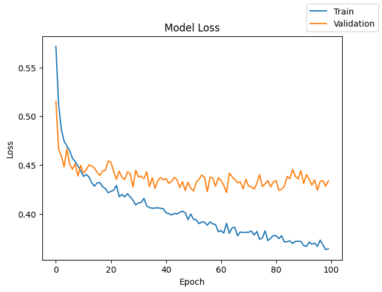

```python
plot(model_history, 'loss')
```

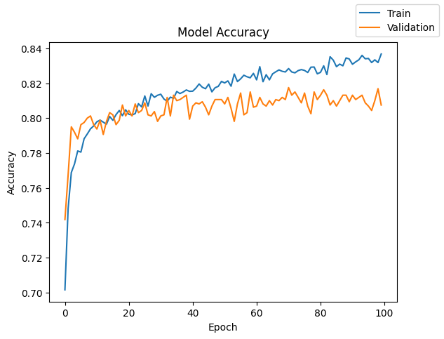

```python
plot(model_history, 'accuracy')
```

```python
model_6_train_perf = model_performance_classification(model, X_train_sm, y_train_sm)
model_6_train_perf
```

```
319/319 ━━━━━━━━━━━━━━━━━━━━ 1s 4ms/step
```

|  | Accuracy | Recall | Precision | F1 Score |
| --- | --- | --- | --- | --- |
| 0 | 0.858516 | 0.858516 | 0.858563 | 0.858512 |

```python
model_6_val_perf = model_performance_classification(model, X_val, y_val)
model_6_val_perf
```

```
50/50 ━━━━━━━━━━━━━━━━━━━━ 0s 1ms/step
```

|  | Accuracy | Recall | Precision | F1 Score |
| --- | --- | --- | --- | --- |
| 0 | 0.8075 | 0.8075 | 0.831356 | 0.816227 |

```python
results.loc[6] = ["NN with Adam, dropout and SMOTE",3,'100','relu,tanh,relu',100,32,model_history.history["loss"][-1],model_history.history["val_loss"][-1],model_history.history["accuracy"][-1],model_history.history["val_accuracy"][-1],round(end-start,2)]
results
```

[output not shown]

## Model Performance Comparison and Final Model Selection

```python
# training performance comparison

models_train_comp_df = pd.concat(
    [
        model_0_train_perf.T,
        model_1_train_perf.T,
        model_2_train_perf.T,
        model_3_train_perf.T,
        model_4_train_perf.T,
        model_5_train_perf.T,
        model_6_train_perf.T
    ],
    axis=1,
)
models_train_comp_df.columns = [
    "Neural Network (SGD, No Regularization)",
    "Neural Network (SGD with Momentum, No Regularization)",
    "Neural Network (Adam , No Regularization)",
    "Neural Network (Adam, dropout [0.2,0.2])",
    "Neural Network (SGD and SMOTE sampling )",
    "Neural Network (Adam, SMOTE sampling)",
    "Neural Network (Adam,dropout [0.4,0.4, 0.2] , SMOTE sampling)",
]
```

```python
# Validation Performance Comparison
models_valid_comp_df = pd.concat(
    [
        model_0_valid_perf.T,
        model_1_valid_perf.T,
        model_2_valid_perf.T,
        model_3_valid_perf.T,
        model_4_valid_perf.T,
        model_5_valid_perf.T,
        model_6_val_perf.T
    ],
    axis=1,
)
models_valid_comp_df.columns = [
    "Neural Network (SGD, No Regularization)",
    "Neural Network (SGD with Momentum, No Regularization)",
    "Neural Network (Adam , No Regularization)",
    "Neural Network (Adam, dropout [0.2,0.2])",
    "Neural Network (SGD and SMOTE sampling )",
    "Neural Network (Adam, SMOTE sampling)",
    "Neural Network (Adam,dropout [0.4,`0.4, 0.2] , SMOTE sampling)"
]
```

```python
models_train_comp_df
```

|  | Neural Network (SGD, No Regularization) | Neural Network (SGD with Momentum, No Regularization) | Neural Network (Adam , No Regularization) | Neural Network (Adam, dropout [0.2,0.2]) | Neural Network (SGD and SMOTE sampling ) | Neural Network (Adam, SMOTE sampling) | Neural Network (Adam,dropout [0.4,0.4, 0.2] , SMOTE sampling) |
| --- | --- | --- | --- | --- | --- | --- | --- |
| Accuracy | 0.862344 | 0.899219 | 0.931406 | 0.885312 | 0.875883 | 0.970859 | 0.858516 |
| Recall | 0.862344 | 0.899219 | 0.931406 | 0.885312 | 0.875883 | 0.970859 | 0.858516 |
| Precision | 0.853932 | 0.895241 | 0.929915 | 0.880863 | 0.876124 | 0.971045 | 0.858563 |
| F1 Score | 0.848227 | 0.895512 | 0.929206 | 0.876101 | 0.875863 | 0.970857 | 0.858512 |

```python
models_valid_comp_df
```

|  | Neural Network (SGD, No Regularization) | Neural Network (SGD with Momentum, No Regularization) | Neural Network (Adam , No Regularization) | Neural Network (Adam, dropout [0.2,0.2]) | Neural Network (SGD and SMOTE sampling ) | Neural Network (Adam, SMOTE sampling) | Neural Network (Adam,dropout [0.4,`0.4, 0.2] , SMOTE sampling) |
| --- | --- | --- | --- | --- | --- | --- | --- |
| Accuracy | 0.856875 | 0.850625 | 0.838750 | 0.857500 | 0.818125 | 0.811875 | 0.807500 |
| Recall | 0.856875 | 0.850625 | 0.838750 | 0.857500 | 0.818125 | 0.811875 | 0.807500 |
| Precision | 0.848930 | 0.840767 | 0.826093 | 0.847249 | 0.831849 | 0.812955 | 0.831356 |
| F1 Score | 0.838660 | 0.843052 | 0.828862 | 0.844355 | 0.823675 | 0.812406 | 0.816227 |

### Final Model Selection

- Our Final model for the case study is Neural Network with Adam Optmizer and Drop Out. It has Train accuracy of 88% and validation accuracy of 86%

```python
epochs = 100
batch_size = 32
```

```python
tf.keras.backend.clear_session()
model = Sequential()
model.add(Dense(100, activation='relu', input_dim=X_train.shape[1]))
model.add(Dropout(0.2))
model.add(Dense(100, activation='tanh'))
model.add(Dropout(0.2))
model.add(Dense(1, activation='sigmoid'))

model.summary()
```

```
Model: "sequential"
```

```
┏━━━━━━━━━━━━━━━━━━━━━━━━━━━━━━━━━━━━━━┳━━━━━━━━━━━━━━━━━━━━━━━━━━━━━┳━━━━━━━━━━━━━━━━━┓
┃ Layer (type)                         ┃ Output Shape                ┃         Param # ┃
┡━━━━━━━━━━━━━━━━━━━━━━━━━━━━━━━━━━━━━━╇━━━━━━━━━━━━━━━━━━━━━━━━━━━━━╇━━━━━━━━━━━━━━━━━┩
│ dense (Dense)                        │ (None, 100)                 │           1,200 │
├──────────────────────────────────────┼─────────────────────────────┼─────────────────┤
│ dropout (Dropout)                    │ (None, 100)                 │               0 │
├──────────────────────────────────────┼─────────────────────────────┼─────────────────┤
│ dense_1 (Dense)                      │ (None, 100)                 │          10,100 │
├──────────────────────────────────────┼─────────────────────────────┼─────────────────┤
│ dropout_1 (Dropout)                  │ (None, 100)                 │               0 │
├──────────────────────────────────────┼─────────────────────────────┼─────────────────┤
│ dense_2 (Dense)                      │ (None, 1)                   │             101 │
└──────────────────────────────────────┴─────────────────────────────┴─────────────────┘
```

```
 Total params: 11,401 (44.54 KB)
```

```
 Trainable params: 11,401 (44.54 KB)
```

```
 Non-trainable params: 0 (0.00 B)
```

```python
model.compile(optimizer='adam', loss='binary_crossentropy', metrics=['accuracy'])
```

```python
start = time.time()
model_history = model.fit(X_train, y_train, epochs=epochs, batch_size=batch_size, validation_data=(X_val, y_val))
end = time.time()
```

```
200/200 ━━━━━━━━━━━━━━━━━━━━ 3s 5ms/step - accuracy: 0.8034 - loss: 0.4783 - val_accuracy: 0.8256 - val_loss: 0.4162
200/200 ━━━━━━━━━━━━━━━━━━━━ 1s 4ms/step - accuracy: 0.8304 - loss: 0.4157 - val_accuracy: 0.8419 - val_loss: 0.3900
200/200 ━━━━━━━━━━━━━━━━━━━━ 2s 5ms/step - accuracy: 0.8383 - loss: 0.3895 - val_accuracy: 0.8475 - val_loss: 0.3752
200/200 ━━━━━━━━━━━━━━━━━━━━ 1s 4ms/step - accuracy: 0.8450 - loss: 0.3778 - val_accuracy: 0.8481 - val_loss: 0.3681
200/200 ━━━━━━━━━━━━━━━━━━━━ 1s 2ms/step - accuracy: 0.8494 - loss: 0.3715 - val_accuracy: 0.8506 - val_loss: 0.3649
200/200 ━━━━━━━━━━━━━━━━━━━━ 1s 3ms/step - accuracy: 0.8477 - loss: 0.3622 - val_accuracy: 0.8550 - val_loss: 0.3627
200/200 ━━━━━━━━━━━━━━━━━━━━ 1s 3ms/step - accuracy: 0.8535 - loss: 0.3585 - val_accuracy: 0.8519 - val_loss: 0.3613
200/200 ━━━━━━━━━━━━━━━━━━━━ 1s 2ms/step - accuracy: 0.8505 - loss: 0.3584 - val_accuracy: 0.8531 - val_loss: 0.3587
200/200 ━━━━━━━━━━━━━━━━━━━━ 1s 3ms/step - accuracy: 0.8593 - loss: 0.3522 - val_accuracy: 0.8550 - val_loss: 0.3585
200/200 ━━━━━━━━━━━━━━━━━━━━ 0s 2ms/step - accuracy: 0.8535 - loss: 0.3524 - val_accuracy: 0.8550 - val_loss: 0.3556
200/200 ━━━━━━━━━━━━━━━━━━━━ 1s 3ms/step - accuracy: 0.8585 - loss: 0.3484 - val_accuracy: 0.8575 - val_loss: 0.3539
200/200 ━━━━━━━━━━━━━━━━━━━━ 1s 3ms/step - accuracy: 0.8553 - loss: 0.3509 - val_accuracy: 0.8569 - val_loss: 0.3535
200/200 ━━━━━━━━━━━━━━━━━━━━ 1s 2ms/step - accuracy: 0.8594 - loss: 0.3431 - val_accuracy: 0.8587 - val_loss: 0.3528
200/200 ━━━━━━━━━━━━━━━━━━━━ 1s 3ms/step - accuracy: 0.8562 - loss: 0.3507 - val_accuracy: 0.8581 - val_loss: 0.3517
200/200 ━━━━━━━━━━━━━━━━━━━━ 1s 2ms/step - accuracy: 0.8587 - loss: 0.3454 - val_accuracy: 0.8562 - val_loss: 0.3514
200/200 ━━━━━━━━━━━━━━━━━━━━ 1s 3ms/step - accuracy: 0.8530 - loss: 0.3424 - val_accuracy: 0.8594 - val_loss: 0.3486
200/200 ━━━━━━━━━━━━━━━━━━━━ 1s 3ms/step - accuracy: 0.8576 - loss: 0.3387 - val_accuracy: 0.8550 - val_loss: 0.3503
200/200 ━━━━━━━━━━━━━━━━━━━━ 1s 3ms/step - accuracy: 0.8592 - loss: 0.3422 - val_accuracy: 0.8575 - val_loss: 0.3519
200/200 ━━━━━━━━━━━━━━━━━━━━ 2s 4ms/step - accuracy: 0.8574 - loss: 0.3354 - val_accuracy: 0.8562 - val_loss: 0.3502
200/200 ━━━━━━━━━━━━━━━━━━━━ 1s 4ms/step - accuracy: 0.8579 - loss: 0.3385 - val_accuracy: 0.8562 - val_loss: 0.3492
200/200 ━━━━━━━━━━━━━━━━━━━━ 1s 4ms/step - accuracy: 0.8632 - loss: 0.3360 - val_accuracy: 0.8581 - val_loss: 0.3472
200/200 ━━━━━━━━━━━━━━━━━━━━ 1s 2ms/step - accuracy: 0.8604 - loss: 0.3359 - val_accuracy: 0.8562 - val_loss: 0.3480
200/200 ━━━━━━━━━━━━━━━━━━━━ 1s 3ms/step - accuracy: 0.8591 - loss: 0.3322 - val_accuracy: 0.8562 - val_loss: 0.3486
200/200 ━━━━━━━━━━━━━━━━━━━━ 1s 3ms/step - accuracy: 0.8680 - loss: 0.3315 - val_accuracy: 0.8587 - val_loss: 0.3506
200/200 ━━━━━━━━━━━━━━━━━━━━ 1s 3ms/step - accuracy: 0.8599 - loss: 0.3383 - val_accuracy: 0.8575 - val_loss: 0.3476
200/200 ━━━━━━━━━━━━━━━━━━━━ 1s 3ms/step - accuracy: 0.8604 - loss: 0.3331 - val_accuracy: 0.8569 - val_loss: 0.3485
200/200 ━━━━━━━━━━━━━━━━━━━━ 1s 3ms/step - accuracy: 0.8612 - loss: 0.3338 - val_accuracy: 0.8581 - val_loss: 0.3487
200/200 ━━━━━━━━━━━━━━━━━━━━ 1s 3ms/step - accuracy: 0.8603 - loss: 0.3355 - val_accuracy: 0.8581 - val_loss: 0.3475
200/200 ━━━━━━━━━━━━━━━━━━━━ 1s 2ms/step - accuracy: 0.8655 - loss: 0.3330 - val_accuracy: 0.8575 - val_loss: 0.3495
200/200 ━━━━━━━━━━━━━━━━━━━━ 1s 3ms/step - accuracy: 0.8612 - loss: 0.3347 - val_accuracy: 0.8556 - val_loss: 0.3486
200/200 ━━━━━━━━━━━━━━━━━━━━ 1s 2ms/step - accuracy: 0.8628 - loss: 0.3308 - val_accuracy: 0.8594 - val_loss: 0.3472
200/200 ━━━━━━━━━━━━━━━━━━━━ 1s 2ms/step - accuracy: 0.8661 - loss: 0.3313 - val_accuracy: 0.8569 - val_loss: 0.3492
200/200 ━━━━━━━━━━━━━━━━━━━━ 0s 2ms/step - accuracy: 0.8650 - loss: 0.3298 - val_accuracy: 0.8550 - val_loss: 0.3491
200/200 ━━━━━━━━━━━━━━━━━━━━ 1s 2ms/step - accuracy: 0.8607 - loss: 0.3278 - val_accuracy: 0.8562 - val_loss: 0.3478
200/200 ━━━━━━━━━━━━━━━━━━━━ 1s 2ms/step - accuracy: 0.8655 - loss: 0.3232 - val_accuracy: 0.8544 - val_loss: 0.3485
200/200 ━━━━━━━━━━━━━━━━━━━━ 1s 3ms/step - accuracy: 0.8632 - loss: 0.3249 - val_accuracy: 0.8581 - val_loss: 0.3483
200/200 ━━━━━━━━━━━━━━━━━━━━ 1s 3ms/step - accuracy: 0.8674 - loss: 0.3264 - val_accuracy: 0.8537 - val_loss: 0.3485
200/200 ━━━━━━━━━━━━━━━━━━━━ 1s 4ms/step - accuracy: 0.8663 - loss: 0.3247 - val_accuracy: 0.8550 - val_loss: 0.3496
200/200 ━━━━━━━━━━━━━━━━━━━━ 1s 4ms/step - accuracy: 0.8673 - loss: 0.3233 - val_accuracy: 0.8531 - val_loss: 0.3489
200/200 ━━━━━━━━━━━━━━━━━━━━ 1s 4ms/step - accuracy: 0.8626 - loss: 0.3245 - val_accuracy: 0.8550 - val_loss: 0.3497
```

[output cut: 45 more lines]

```
200/200 ━━━━━━━━━━━━━━━━━━━━ 1s 2ms/step - accuracy: 0.8713 - loss: 0.3099 - val_accuracy: 0.8562 - val_loss: 0.3538
200/200 ━━━━━━━━━━━━━━━━━━━━ 1s 3ms/step - accuracy: 0.8738 - loss: 0.3060 - val_accuracy: 0.8575 - val_loss: 0.3522
200/200 ━━━━━━━━━━━━━━━━━━━━ 1s 3ms/step - accuracy: 0.8684 - loss: 0.3107 - val_accuracy: 0.8531 - val_loss: 0.3534
200/200 ━━━━━━━━━━━━━━━━━━━━ 1s 2ms/step - accuracy: 0.8684 - loss: 0.3063 - val_accuracy: 0.8556 - val_loss: 0.3542
200/200 ━━━━━━━━━━━━━━━━━━━━ 1s 3ms/step - accuracy: 0.8669 - loss: 0.3109 - val_accuracy: 0.8531 - val_loss: 0.3563
200/200 ━━━━━━━━━━━━━━━━━━━━ 1s 2ms/step - accuracy: 0.8721 - loss: 0.3098 - val_accuracy: 0.8562 - val_loss: 0.3546
200/200 ━━━━━━━━━━━━━━━━━━━━ 1s 2ms/step - accuracy: 0.8684 - loss: 0.3108 - val_accuracy: 0.8587 - val_loss: 0.3537
200/200 ━━━━━━━━━━━━━━━━━━━━ 1s 3ms/step - accuracy: 0.8732 - loss: 0.3018 - val_accuracy: 0.8569 - val_loss: 0.3555
200/200 ━━━━━━━━━━━━━━━━━━━━ 1s 2ms/step - accuracy: 0.8737 - loss: 0.3033 - val_accuracy: 0.8581 - val_loss: 0.3566
200/200 ━━━━━━━━━━━━━━━━━━━━ 1s 4ms/step - accuracy: 0.8716 - loss: 0.3095 - val_accuracy: 0.8600 - val_loss: 0.3569
200/200 ━━━━━━━━━━━━━━━━━━━━ 1s 4ms/step - accuracy: 0.8722 - loss: 0.3004 - val_accuracy: 0.8556 - val_loss: 0.3534
200/200 ━━━━━━━━━━━━━━━━━━━━ 1s 4ms/step - accuracy: 0.8709 - loss: 0.3071 - val_accuracy: 0.8537 - val_loss: 0.3546
200/200 ━━━━━━━━━━━━━━━━━━━━ 1s 4ms/step - accuracy: 0.8734 - loss: 0.3038 - val_accuracy: 0.8556 - val_loss: 0.3557
200/200 ━━━━━━━━━━━━━━━━━━━━ 1s 3ms/step - accuracy: 0.8664 - loss: 0.3055 - val_accuracy: 0.8556 - val_loss: 0.3542
200/200 ━━━━━━━━━━━━━━━━━━━━ 1s 3ms/step - accuracy: 0.8727 - loss: 0.3035 - val_accuracy: 0.8531 - val_loss: 0.3568
```

```python
print("Time taken in seconds ",end-start)
```

```
Time taken in seconds  77.14283084869385
```

```python
final_model_train_perf = model_performance_classification(model, X_train, y_train)
final_model_val_perf = model_performance_classification(model, X_val, y_val)
final_model_test_perf = model_performance_classification(model, X_test, y_test)
```

```
200/200 ━━━━━━━━━━━━━━━━━━━━ 1s 3ms/step
50/50 ━━━━━━━━━━━━━━━━━━━━ 0s 2ms/step
63/63 ━━━━━━━━━━━━━━━━━━━━ 0s 4ms/step
```

```python
final_model_score = pd.concat(
    [final_model_train_perf.T, final_model_val_perf.T, final_model_test_perf.T], axis=1
)

final_model_score.columns = [
    "Final Model Train metrics",
    "Final Model Validation metrics",
    "Final Model Test metrics"
   ]

final_model_score
```

|  | Final Model Train metrics | Final Model Validation metrics | Final Model Test metrics |
| --- | --- | --- | --- |
| Accuracy | 0.883125 | 0.853125 | 0.863500 |
| Recall | 0.883125 | 0.853125 | 0.863500 |
| Precision | 0.878135 | 0.841768 | 0.854332 |
| F1 Score | 0.873846 | 0.839432 | 0.852906 |

## Actionable Insights and Business Recommendations

- The Bank can deploy the final model to predict whether the customers churn or not .
- The model can correctly predict 86% of times when deployed.
- Can be further tuned by changing epochs, batchsize, learning rate, adding layers, initializers etc.
- Thru EDA we figured some features like (location, age, gender, salary) are important for the bank to look into as well.
- Our final model accuracy is consistent across train, validation and test sets and so it is considered as a best model for the bank churn prediction.